# PA1_template.Rmd

Antoin van Gemert

8 januari 2018

# 1. Loading and preprocessing the data

## First download the dataset from the course website: “Activity monitoring data.csv”

## 1.1 the data is loaded into variable ‘act’, and checks have been performed using the functions ‘summary’ and ‘head’

## 1.2 in this stage no further processing of the data is necessary

```r
act <- read.csv("activity.csv")
summary(act)
```

```
##      steps                date          interval
##  Min.   :  0.00   2012-10-01:  288   Min.   :   0.0
##  1st Qu.:  0.00   2012-10-02:  288   1st Qu.: 588.8
##  Median :  0.00   2012-10-03:  288   Median :1177.5
##  Mean   : 37.38   2012-10-04:  288   Mean   :1177.5
##  3rd Qu.: 12.00   2012-10-05:  288   3rd Qu.:1766.2
##  Max.   :806.00   2012-10-06:  288   Max.   :2355.0
##  NA's   :2304     (Other)   :15840
```

```r
head(act)
```

```
##   steps       date interval
## 1    NA 2012-10-01        0
## 2    NA 2012-10-01        5
## 3    NA 2012-10-01       10
## 4    NA 2012-10-01       15
## 5    NA 2012-10-01       20
## 6    NA 2012-10-01       25
```

# 2. What is the mean total number of steps taken per day?

### For this part of the assignment, you can ignore the missing values in the dataset.

## 2.1 Calculate the total number of steps taken per day. The result is stored in variable ‘spd’.

```r
spd <- aggregate(steps ~ date, act, sum, na.rm = TRUE)
head(spd)
```

```
##         date steps
## 1 2012-10-02   126
## 2 2012-10-03 11352
## 3 2012-10-04 12116
## 4 2012-10-05 13294
## 5 2012-10-06 15420
## 6 2012-10-07 11015
```

## 2.2 Make a histogram of the total number of steps taken each day. The histogram is caputerd in:“Histogram total number of steps taken each day.png”

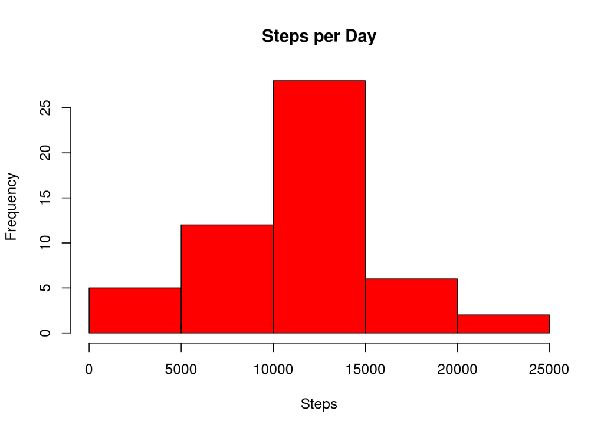

```r
hist(spd$steps, col = "red", xlab = "Steps", main = "Steps per Day")
```

## 2.3 Calculate and report the mean and median of the total number of steps taken per day. ### The mean total number of steps is stored in variable ‘meanspd’, the mean number of steps at this moment is 10766.19

```r
meanspd <- mean(spd$steps)
head(meanspd)
```

```
## [1] 10766.19
```

### The median total number of steps is stored in variable ‘medspd’, the median number of steps at this moment is 10765

```r
medspd <- median(spd$steps)
medspd
```

```
## [1] 10765
```

# 3. What is the average daily activity pattern?

## 3.1 Make a time series plot (i.e) of the 5-minute interval (x - axis) and the average number of steps taken, averaged across all days (y - axis). The plot is captured in:“Plot average number of steps.png”

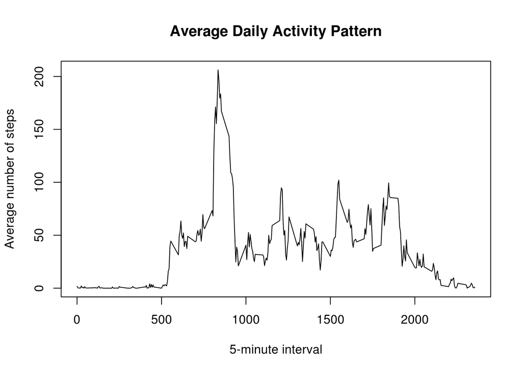

```r
spi <- aggregate(steps ~ interval, data = act, mean, na.rm = TRUE)
plot(steps ~ interval, data = spi, type = "l", xlab = "5-minute interval", ylab = "Average number of steps", main = "Average Daily Activity Pattern")
```

```r
maxsteps <- spi[which.max(spi$steps), ]$interval
maxsteps
```

```
## [1] 835
```

# 4. Imputing missing values

## 4.1 Calculate and report the total number of missing values in the dataset(i.e. the total number of rows with s)

### The variable ’misval’contains the number of missing values, the number of NA’s at this moment is 2304.

```r
misval <- sum(is.na(act$steps))
misval
```

```
## [1] 2304
```

## 4.2 Devise a strategy for filling in all the missing values in the dataset. The strategy does not need to be sophistacated.

### For this assignment the strategy for filling missing values is using the means of the intervals.

```r
mspi <- function(interval){
  spi[spi$interval == interval, ]$steps
}
```

## 4.3 Create a new dataset that is equal to the original dataset but with the missing data filled in.

### actnona contains the new data set with the missing data filled in

```r
actnona <- act
for (i in 1:nrow(actnona)) {
  if(is.na(actnona[i,]$steps)){
    actnona[i,]$steps <- mspi(actnona[i,]$interval)
  }
}
```

### Checking if all NA’s are filled, we can now verify there are 0 NA’s in the new dataset

```r
misval <- sum(is.na(actnona$steps))
misval
```

```
## [1] 0
```

## 4.4 Make a histogram of the total number of steps taken each day and calculate and report the mean and median total number of steps taken per day.

### The histogram is captured in:“Total number of steps taken each day.png”

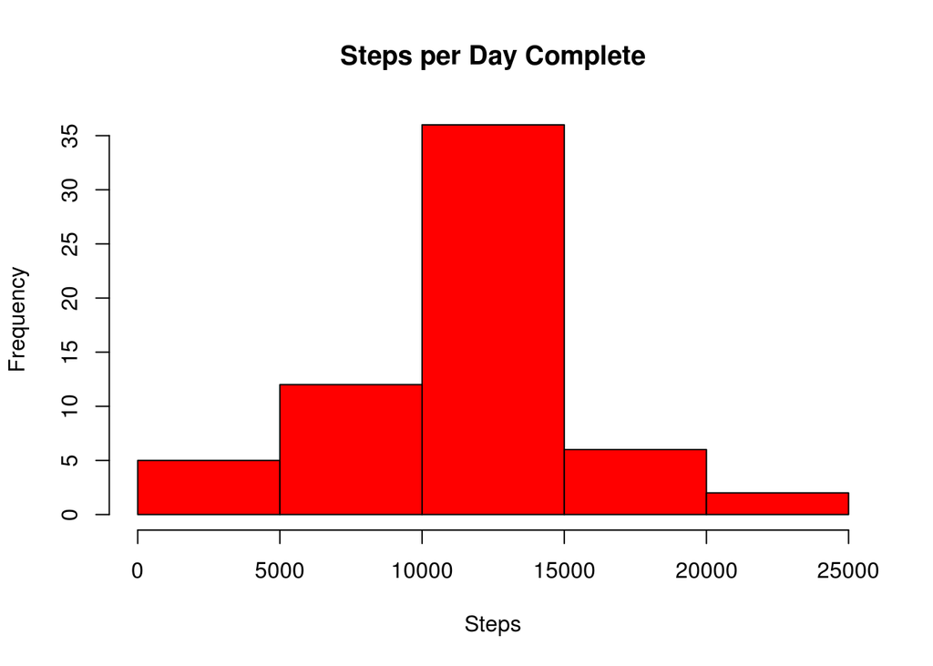

```r
spdnona <- aggregate(steps ~ date, data = actnona, sum)
hist(spdnona$steps, col = "red", xlab = "Steps", main = "Steps per Day Complete")
```

### The new mean is stored in “meanspdnona”, the new mean is 10766.19 at this moment.

```r
meanspdnona <- mean(spdnona$steps)
meanspdnona
```

```
## [1] 10766.19
```

### The new median is stored in “medspdnona”, the new median is 10766.19 at this moment.

```r
medspdnona <- median(spdnona$steps)
medspdnona
```

```
## [1] 10766.19
```

### In the new dataset the new mean is equal to the new median

```r
meanspdnona == medspdnona
```

```
## [1] TRUE
```

# 5. Are there differences in activity patterns weekdays and weekends?

## 5.1 Create a new factor variable in the dataset with two levels - “weekday” and “weekend” indicating whether a given date is a weekday or weekend day.

### (My computer uses local settings. To create the variable ‘weekend’ local names of weekdays are used, “zaterdag” means “Saturday”, “zondag” means “Sunday”).

```r
weekend <- weekdays(as.Date(actnona$date)) %in% c("zaterdag", "zondag")
actnona$daytype <- "weekday"
actnona$daytype[weekend == TRUE] <- "weekend"
actnona$daytype <- as.factor(actnona$daytype)
```

### factor variable with two levels - “weekday” and “weekend”.

```r
str(actnona)
```

```
## 'data.frame':    17568 obs. of  4 variables:
##  $ steps   : num  1.717 0.3396 0.1321 0.1509 0.0755 ...
##  $ date    : Factor w/ 61 levels "2012-10-01","2012-10-02",..: 1 1 1 1 1 1 1 1 1 1 ...
##  $ interval: int  0 5 10 15 20 25 30 35 40 45 ...
##  $ daytype : Factor w/ 2 levels "weekday","weekend": 1 1 1 1 1 1 1 1 1 1 ...
```

```r
head(actnona)
```

```
##       steps       date interval daytype
## 1 1.7169811 2012-10-01        0 weekday
## 2 0.3396226 2012-10-01        5 weekday
## 3 0.1320755 2012-10-01       10 weekday
## 4 0.1509434 2012-10-01       15 weekday
## 5 0.0754717 2012-10-01       20 weekday
## 6 2.0943396 2012-10-01       25 weekday
```

```r
nwi <- aggregate(steps ~ interval + daytype, actnona, mean)
names(nwi)[3] <- "mean_steps"
head(nwi, 5)
```

```
##   interval daytype mean_steps
## 1        0 weekday 2.25115304
## 2        5 weekday 0.44528302
## 3       10 weekday 0.17316562
## 4       15 weekday 0.19790356
## 5       20 weekday 0.09895178
```

## 5.2 Make a panel plot containing a time series plot (i.e.) of the 5-minutes interval (x-axis) and the average nimber of steps taken, averaged across all weekday days or weekend days (y-axis). The time series plot is captured in:“Time series plot average number of steps weekdays vs. weekends.png”

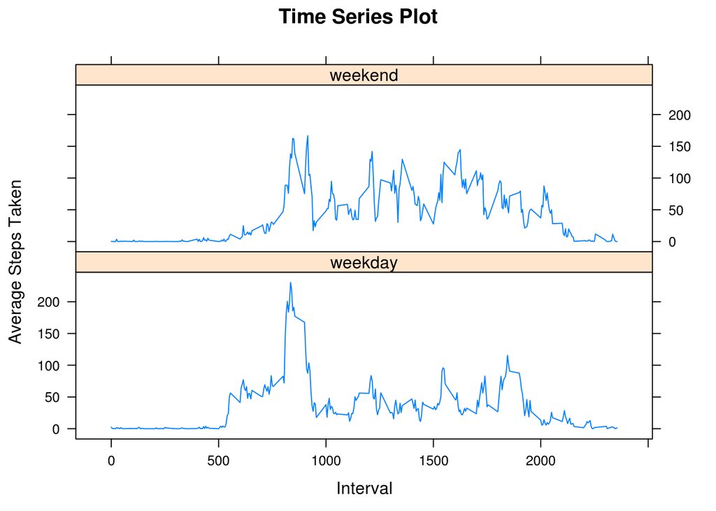

```r
library(lattice)
xyplot(mean_steps ~ interval | daytype, nwi, type = "l", layout = c(1,2), main = "Time Series Plot", xlab = "Interval", ylab = "Average Steps Taken")
```